# 20250520_waterquality

```r
library(tidyverse)
library(tidytuesdayR)
```

```r
library(ggplot2)
library(lubridate)
library(ggforce)
library(lme4)
```

#Get data

```r
water_quality <- readr::read_csv('https://raw.githubusercontent.com/rfordatascience/tidytuesday/main/data/2025/2025-05-20/water_quality.csv')
weather <- readr::read_csv('https://raw.githubusercontent.com/rfordatascience/tidytuesday/main/data/2025/2025-05-20/weather.csv')
```

#init. thoughts

These dataset contain information about the water quality, location, weather, and city council in Sydney Australia.

It might be interesting to see if certain city councils are responsible for better or worse water quality–might be difficult to control for other variables because they are likely to be confounds (e.g., some councils might oversee areas with worse pollution unrelated to their policies).

Still, I can make some informative plots.

Here are some questions from the gihub page: * Has the water quality declined over this period? * How does rainfall impact E-coli bacteria levels? * Are some swimming sites particularly prone to high bacteria levels following rain?

Lets first explore the data and see what we’re working with.

#WaterQualityOverTime

To do this we will have to first make a new variable from the data variable in the water_quality dataset. The purpose of this is to make the x axis more meaningful and easier to interpret when the date variable is plotted on the x axis.

We will make a new dataset called yr_avg_water_quality with the variables “year” and “avg_bacteria_cfu” which is the average bacteria count across a year.

```r
yr_avg_water_quality <-water_quality %>%
  group_by(region, year(date)) %>%
  summarize(avg_bacteria_cfu = mean(enterococci_cfu_100ml, na.rm = TRUE))
yr_avg_water_quality <- yr_avg_water_quality %>%
rename(year = "year(date)")
```

##fig. yrly_avg

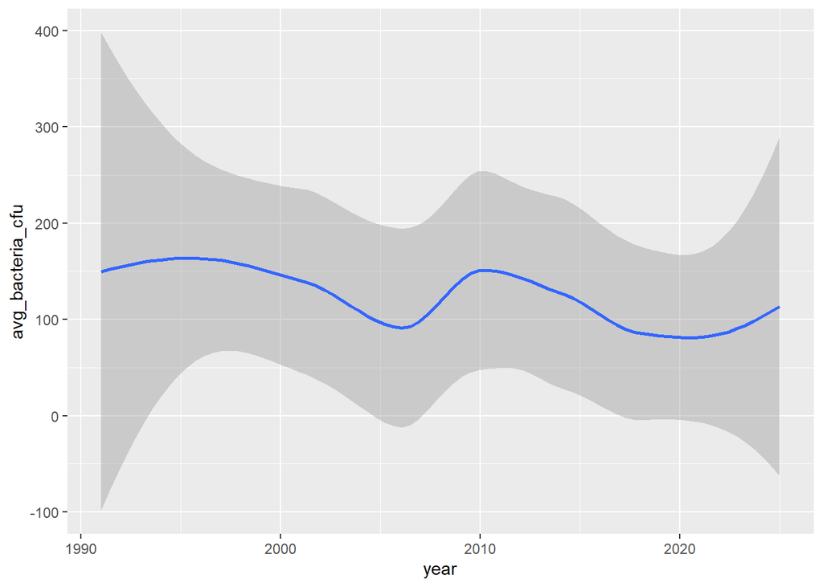

```r
yr_avg_water_quality %>%
  ggplot(aes(x = year, y = avg_bacteria_cfu)) +
  geom_smooth()
```

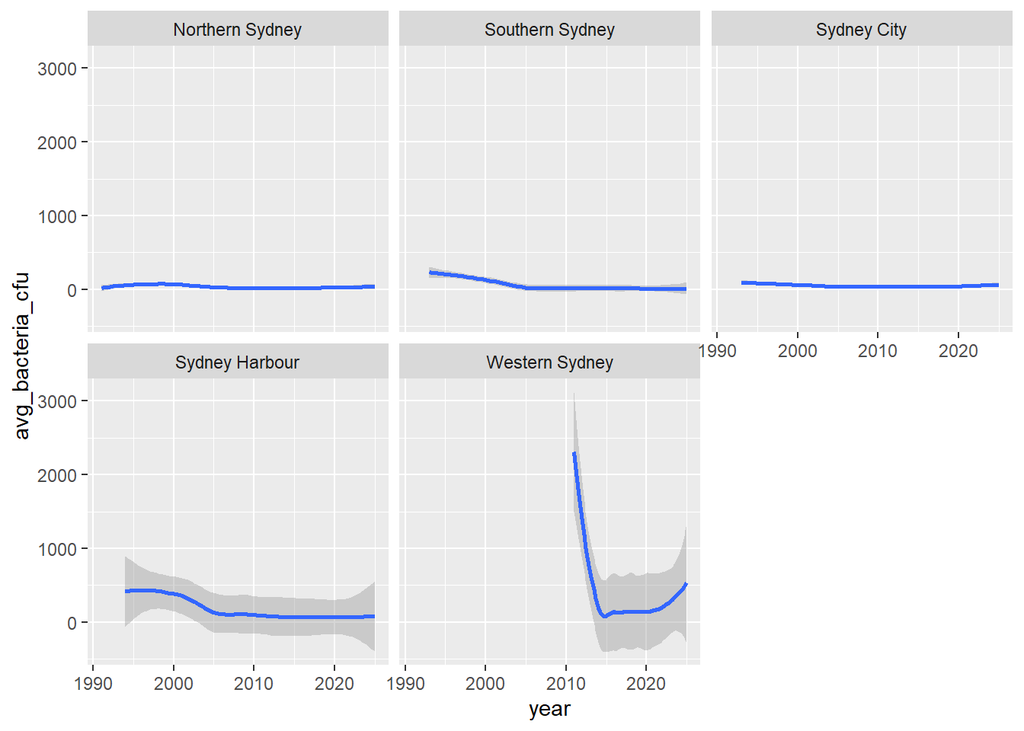

```r
yr_avg_water_quality %>%
  ggplot(aes(x = year, y = avg_bacteria_cfu)) +
  geom_smooth()+
  facet_wrap(~region)
```

##analysis_correlation

```r
water_quality %>%
  mutate(date_num = as.numeric(date)) %>%
  summarize(
    correlation = cor.test(date_num, enterococci_cfu_100ml, method = "pearson", use = "complete.obs")$estimate,
p_value = cor.test(date_num, enterococci_cfu_100ml, method = "pearson", use = "complete.obs")$p.value)
```

```
## # A tibble: 1 × 2
##   correlation     p_value
##         <dbl>       <dbl>
## 1     -0.0143 0.000000552
```

```r
water_quality %>%
  mutate(date_num = as.numeric(date)) %>%
  group_by(swim_site) %>%
  summarize(
    correlation = cor.test(date_num, enterococci_cfu_100ml, method = "pearson", use = "complete.obs")$estimate,
    p_value = cor.test(date_num, enterococci_cfu_100ml, method = "pearson", use = "complete.obs")$p.value
  )
```

```
## # A tibble: 79 × 3
##    swim_site           correlation p_value
##    <chr>                     <dbl>   <dbl>
##  1 Avalon Beach           -0.0351  0.111
##  2 Balmoral Baths         -0.0216  0.395
##  3 Bilarong Reserve        0.0399  0.315
##  4 Bilgola Beach          -0.0141  0.519
##  5 Boat Harbour           -0.0504  0.0119
##  6 Bondi Beach            -0.0625  0.00402
##  7 Bronte Beach            0.00717 0.737
##  8 Bungan Beach           -0.0381  0.0828
##  9 Cabarita Beach         -0.0538  0.0440
## 10 Callan Park Seawall     0.00223 0.972
## # ℹ 69 more rows
```

The overall correlation between date and bacteria concentration is significantly negative so you can say that the amount of bacteria is decreasing over time.

#RainfallBacteria

To figure out if there is a relationship between water quality and rainfall, we will need to merge the water_quality and weather datasets so that we line up the precipitation_mm variable from the weather df with the correct data variable from the water quality df and it doesn’t create additional observations.

```r
water_quality_merge <- left_join(water_quality, weather, by = "date")
```

##correlationPrecipXBacteria

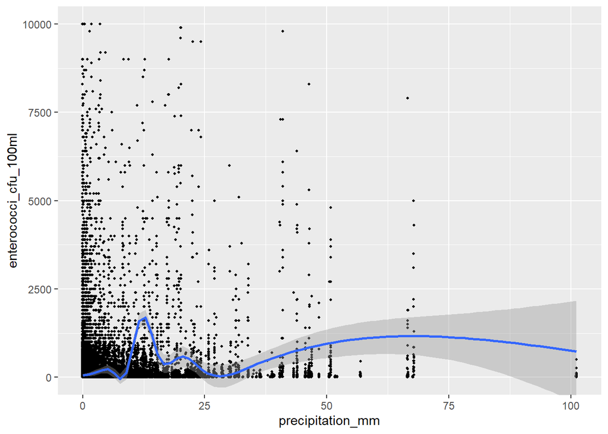

```r
water_quality_merge %>%
  ggplot(aes(x = precipitation_mm, y = enterococci_cfu_100ml)) +
  geom_jitter(size = .75)+
  geom_smooth() +
  coord_cartesian(ylim = c(0, 10000))
```

```r
water_quality_merge %>%
  summarize(
    correlation = cor.test(precipitation_mm, enterococci_cfu_100ml, method = "pearson", use = "complete.obs")$estimate,
p_value = cor.test(precipitation_mm, enterococci_cfu_100ml, method = "pearson", use = "complete.obs")$p.value)
```

```
## # A tibble: 1 × 2
##   correlation  p_value
##         <dbl>    <dbl>
## 1      0.0252 7.95e-19
```

```r
water_quality_merge %>%
  group_by(swim_site) %>%
  summarize(
    correlation = cor.test(precipitation_mm, enterococci_cfu_100ml, method = "pearson", use = "complete.obs")$estimate,
    p_value = cor.test(precipitation_mm, enterococci_cfu_100ml, method = "pearson", use = "complete.obs")$p.value
  )
```

```
## # A tibble: 79 × 3
##    swim_site           correlation  p_value
##    <chr>                     <dbl>    <dbl>
##  1 Avalon Beach            0.0248  2.60e- 1
##  2 Balmoral Baths          0.141   2.60e- 8
##  3 Bilarong Reserve        0.0698  7.83e- 2
##  4 Bilgola Beach           0.00122 9.56e- 1
##  5 Boat Harbour           -0.00148 9.41e- 1
##  6 Bondi Beach             0.147   1.20e-11
##  7 Bronte Beach            0.107   4.59e- 7
##  8 Bungan Beach            0.0740  7.42e- 4
##  9 Cabarita Beach          0.120   7.13e- 6
## 10 Callan Park Seawall     0.228   2.44e- 4
## # ℹ 69 more rows
```

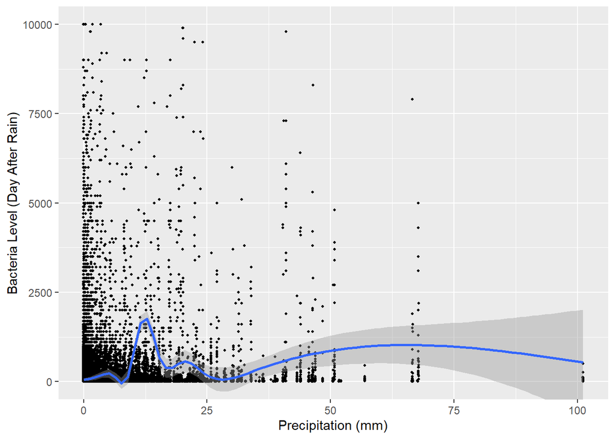

```r
water_quality_shifted <- water_quality_merge %>%
  arrange(date) %>%
  group_by(date) %>%
  mutate(next_day_bacteria = lead(enterococci_cfu_100ml, 1))  # Shift by 1 day

# Now, you can plot the correlation between precipitation on a given day and the bacteria level on the next day
ggplot(water_quality_shifted, aes(x = precipitation_mm, y = next_day_bacteria)) +
  geom_jitter(size = .75) +
  geom_smooth()+
  coord_cartesian(ylim = c(0, 10000)) +
  labs(
    x = "Precipitation (mm)",
    y = "Bacteria Level (Day After Rain)"
  )
```